# Cyclistic Bike-share: A Case Study (Prepare-Process Phase)

Cedrick C. Sante

*Dataset taken from Motivate International Inc. under this [license](https://ride.divvybikes.com/data-license-agreement)*

# Preparing/ Checking for Data Cleanliness

## Converted the started_at & end_at columns to 37:30:55 format of each datasets

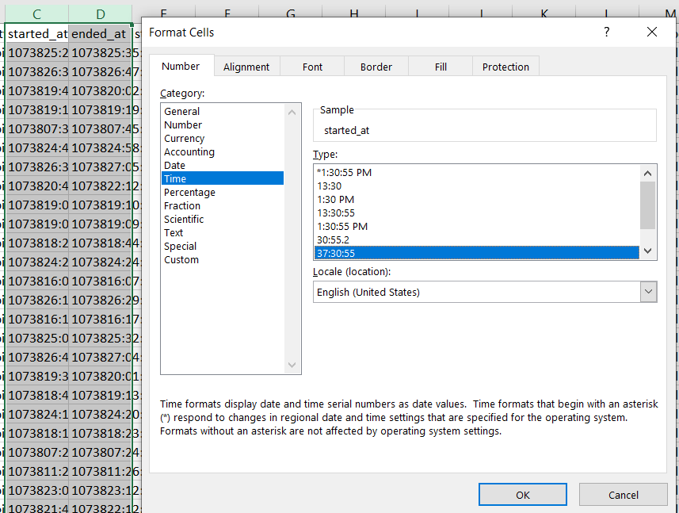

## Added Columns for ride_length based on the previous converted columns, day_of_week, and month

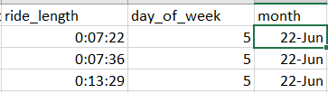

## Merge all datasets:

```r
library('tidyverse')
library('lubridate')

b1 <- read_csv("202206-divvy-tripdata.csv")
b2 <- read_csv("202205-divvy-tripdata.csv")
bt <- full_join(b1, b2)
b3 <- read_csv("202204-divvy-tripdata.csv")
bt <- full_join(bt, b3)
b4 <- read_csv("202203-divvy-tripdata.csv")
bt <- full_join(bt, b4)
b5 <- read_csv("202202-divvy-tripdata.csv")
bt <- full_join(bt, b5)
b6 <- read_csv("202201-divvy-tripdata.csv")
bt <- full_join(bt, b6)
b7 <- read_csv("202112-divvy-tripdata.csv")
bt <- full_join(bt, b7)
b8 <- read_csv("202111-divvy-tripdata.csv")
bt <- full_join(bt, b8)
b9 <- read_csv("202110-divvy-tripdata.csv")
bt <- full_join(bt, b9)
b10 <- read_csv("202109-divvy-tripdata.csv")
bt <- full_join(bt, b10)
b11 <- read_csv("202108-divvy-tripdata.csv")
bt <- full_join(bt, b11)
b12 <- read_csv("202107-divvy-tripdata.csv")
bt <- full_join(bt, b12)
```

## Explore Data

### Ride Types:

```r
bt %>% group_by(rideable_type) %>% summarize()
```

| rideable_type |
| --- |
| classic_bike |
| docked_bike |
| electric_bike |

```r
NA
```

### Types of Customers/Subscribers

```r
bt %>% group_by(member_casual) %>% summarize()
```

| member_casual |
| --- |
| casual |
| member |

```r
NA
```

### Day of week (1 is Sunday, 2 is Monday, etc…)

```r
bt %>% group_by(day_of_week) %>% summarize()
```

| day_of_week |
| --- |
| 1 |
| 2 |
| 3 |
| 4 |
| 5 |
| 6 |
| 7 |

```r
NA
```

### Month data is gathered:

```r
bt %>% group_by(bt$month) %>% summarize()
```

| bt$month |
| --- |
| 01-2022 |
| 02-2022 |
| 03-2022 |
| 04-2022 |
| 05-2022 |
| 06-2022 |
| 07-2021 |
| 08-2021 |
| 09-2021 |
| 10-2021 |

[output cut: 2 more lines]

```r
NA
```

# Analysis

## Pre-analysis for common Statistics values

Mean of ride_length

```r
seconds_to_period(mean(bt$ride_length, na.rm = TRUE))
```

```
[1] "19M 6.75845036665828S"
```

Max ride_length

```r
seconds_to_period(max(bt$ride_length, na.rm = TRUE))
```

```
[1] "4d 3H 44M 45S"
```

```r
filter(bt, ride_length == 359085) #359085 seconds = "4d 3H 44M 45S"
```

| ride_id | rideable_type | started_at | ended_at | start_station_name | start_station_id | end_station_name | end_station_id | start_lat | start_lng | end_lat | end_lng | member_casual | ride_length | day_of_week | month |
| --- | --- | --- | --- | --- | --- | --- | --- | --- | --- | --- | --- | --- | --- | --- | --- |
| 3016A02D25A5C12D | docked_bike | 1066299:28:35 | 1066399:13:20 | State St & Pearson St | TA1307000061 | State St & Pearson St | TA1307000061 | 41.89745 | -87.62872 | 41.89745 | -87.62872 | casual | 99:44:45 | 7 | 08-2021 |

```r
NA
```

Mode of day_of_week

```r
# no built-in function for mode in R, hence code for one
getmode <- function(v) {
   uniqv <- unique(v)
   uniqv[which.max(tabulate(match(v, uniqv)))]
}

getmode(bt$day_of_week) #7 is Saturday
```

```
[1] 7
```

## Pivot tables

Average ride_length of Member types:

```r
bt %>% group_by(member_casual) %>%
  summarise(average_ride_length = seconds_to_period(mean(ride_length, na.rm = TRUE)))
```

| member_casual | average_ride_length |
| --- | --- |
| casual | 27M 7.30907815599039S |
| member | 12M 58.9965817663685S |

```r
NA
```

Average ride_length per day of week:

```r
bt %>% group_by(day_of_week) %>%
  summarise(average_ride_length = seconds_to_period(mean(ride_length, na.rm = TRUE)))
```

| day_of_week | average_ride_length |
| --- | --- |
| 1 | 23M 35.3995560642165S |
| 2 | 18M 38.6585357018569S |
| 3 | 16M 23.5576150919884S |
| 4 | 16M 13.2998815431807S |
| 5 | 16M 59.0157583847511S |
| 6 | 18M 14.3224179362719S |
| 7 | 22M 41.6147307451627S |

```r
NA
```

Numbers of rides per day of week

```r
bt %>% group_by(day_of_week) %>% summarise(number_of_rides = n_distinct(ride_id))
```

| day_of_week | number_of_rides |
| --- | --- |
| 1 | 865982 |
| 2 | 772971 |
| 3 | 795936 |
| 4 | 801978 |
| 5 | 851020 |
| 6 | 832267 |
| 7 | 979638 |

```r
NA
```

## Data useful for viz:

-Number of Casual Riders vs. Annual Subscribers

```r
bt %>% group_by(member_casual) %>%
  summarise(number_of_rides = (n_distinct(ride_id)))
```

| member_casual | number_of_rides |
| --- | --- |
| casual | 2557634 |
| member | 3341262 |

-Number of rides per month

```r
bt %>% group_by(bt$month, member_casual) %>%
  summarise(number_of_rides = (n_distinct(ride_id)))
```

| bt$month | member_casual | number_of_rides |
| --- | --- | --- |
| 01-2022 | casual | 18520 |
| 01-2022 | member | 85247 |
| 02-2022 | casual | 21416 |
| 02-2022 | member | 94191 |
| 03-2022 | casual | 89882 |
| 03-2022 | member | 194151 |
| 04-2022 | casual | 126415 |
| 04-2022 | member | 244821 |
| 05-2022 | casual | 280406 |
| 05-2022 | member | 354426 |

[output cut: 14 more lines]

-Number of rides per week:

```r
bt %>% group_by(day_of_week, member_casual) %>%
  summarise(number_of_rides = (n_distinct(ride_id)))
```

| day_of_week | member_casual | number_of_rides |
| --- | --- | --- |
| 1 | casual | 467089 |
| 1 | member | 398929 |
| 2 | casual | 303983 |
| 2 | member | 469020 |
| 3 | casual | 277764 |
| 3 | member | 518209 |
| 4 | casual | 285474 |
| 4 | member | 516539 |
| 5 | casual | 325160 |
| 5 | member | 525899 |

[output cut: 4 more lines]

# Share (Visualizations)

## Number of Casual Riders vs. Annual Subscribers

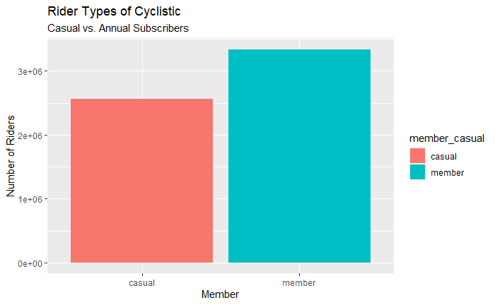

```r
df <- bt %>% group_by(member_casual) %>%
  summarise(number_of_rides = (n_distinct(ride_id)))

ggplot(df) + geom_col(mapping = aes(x = member_casual, y = number_of_rides,
                                      fill = member_casual)) +
    labs(x = "Member", y = "Number of Riders",
         title = "Rider Types of Cyclistic",
         subtitle = "Casual vs. Annual Subscribers")
```

*-Though the number of members who avail the annual subscription is greater, it is **deceptive** to the **actual usage** of Cyclistic’s bikes.*

## Number of Rides per Month

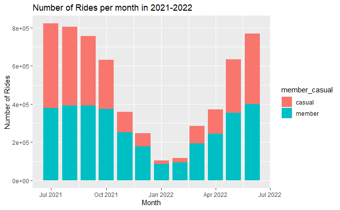

```r
df <- bt %>% select(month, member_casual, ride_id)
df <- mutate(df, month = my(df$month))

ggplot(df) + geom_bar(mapping = aes(x = month, fill = member_casual)) +
  labs(x = "Month", y = "Number of Rides", title = "Number of Rides per month in 2021-2022")
```

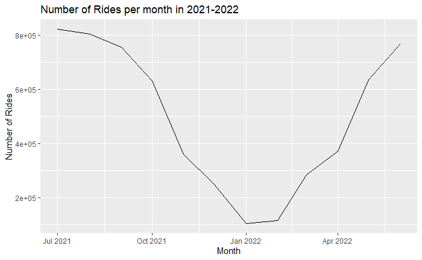

```r
df <- df %>% group_by(month) %>% summarise(number_of_rides = n_distinct(ride_id))

ggplot(df) + geom_line(mapping = aes(x = month, y = number_of_rides)) +
  labs(x = "Month", y = "Number of Rides", title = "Number of Rides per month in 2021-2022")
```

*-Number of rides, especially by casuals, lowers around **November to February,** which makes sense because of rainy/winter season. It starts to return around **March onwards**, and get higher upon beginning and time of summer.*

-Hence, marketing should be focused as **summer times approach, during it, and few months after (around March to September).**

## Number of Rides in a Week

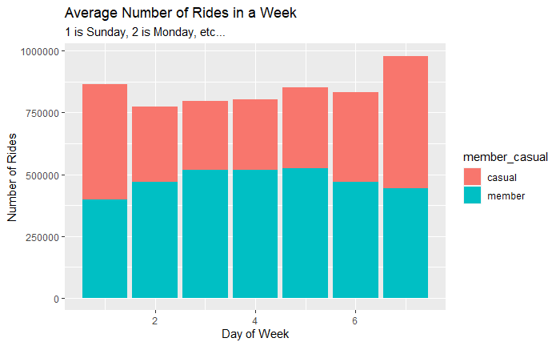

```r
ggplot(bt) + geom_bar(mapping = aes(x = day_of_week, fill = member_casual)) +
  labs(x = "Day of Week", y = "Number of Rides",
       title = "Average Number of Rides in a Week",
       subtitle = "1 is Sunday, 2 is Monday, etc...")
```

*-Data shows that there are more users during weekend, especially casuals.*

-Hence, promos like giving discounts for annual memberships’ availability should be based in there, like **limited time offer during weekends.**

## Ride Length in a Week

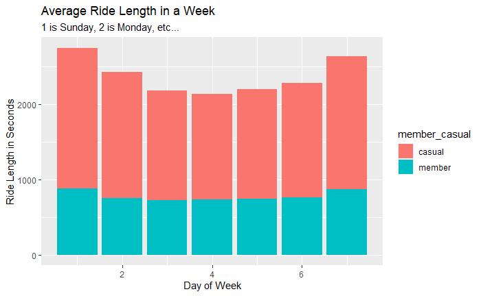

```r
df <- bt %>% select(day_of_week, member_casual, ride_length)
df <- df %>% group_by(day_of_week, member_casual) %>% summarise(ave_ride_len = mean(ride_length, na.rm = TRUE))
ggplot(df) + geom_col(mapping = aes(x = day_of_week, y = df$ave_ride_len, fill = member_casual)) +
  labs(x = "Day of Week", y = "Ride Length in Seconds",
       title = "Average Ride Length in a Week",
       subtitle = "1 is Sunday, 2 is Monday, etc...")
```

*-It could be seen that Casual users, as a group, collectively uses our bike in a **longer period of time**. This increases our outward cashflow, towards fund for maintenance for larger number of bikes that are used by them, even if they actually spend less money for our service.*

-Hence, this reinforces further the need of converting these casual users to our annual subscription.

# Conclusion

-Marketing should be ramped up as **summer** approaches, during, and a few months after it.

-Promos like limited time offerings should be given during **weekends**.

-Though annual subscribers are greater in number, casual members should still be converted, as that group could cost us more in the long run with maintenance of our bikes.